# BayeScan

Óscar Romero Báez

2022-05-21

This analysis is part of my research project and this script will be used to analyze the outputs obtained from the BayeScan software from the SNP data obtained from four different sites where the lizard *Sceloporus grammicus* was sampled. The `plot_bayescan()` function that comes with the BayeScan software will be used for this propose. (Follows M and OE Gaggiotti, 2008).

Because the sampling sites belong to two forest areas and two agricultural areas, the analysis was carried out separately, analyzing only the forest sites in one test and the agricultural sites in another.

The purpose of testing separately is because we want to see if there are candidate SNPs for selection that differ due to the different habitat types that organisms inhabit.

The format that BayeScan requires to run can be obtained using the PGDSpider program (Lischer HEL and Excoffier L, 2012). If you need to download both programs, go to the following links: http://cmpg.unibe.ch/software/BayeScan/download.html (BayeScan), http://www.cmpg.unibe.ch/software/PGDSpider/#Download_and_Installation_Instructions (PGDSpider).

Go to the **Sgrammicus_SelectionTest** folder to work with.

1. Run BayeScan

Parameters used to run BayeScan

Parameters Forest sites `Analysis/BayeScan/Program/BayeScan2.1_macos64bits Data/BayeScan/Sg_For_Bayescan` `-o Analysis/BayeScan/Results/Sg_For/Sg_For_Bayescan_RE1 -threads 4 -n 5000 -thin 20 -nbp 20 -pilot 1000 -burn 10000`

Parameters Agricultural sites `Analysis/BayeScan/Program/BayeScan2.1_macos64bits Data/BayeScan/Sg_Agr_Bayescan` `-o Analysis/BayeScan/Results/Sg_Agr/Sg_Agr_Bayescan_RE1 -threads 6 -n 5000 -thin 20 -nbp 20 -pilot 1000 -burn 10000`

2. Packages required

```r
library(ggplot2)
```

3. Source to plot_bayescan() function that comes with BayeScan

```r
source("Analysis/BayeScan/Program/plot_R.r")
```

4. Load BayeScan outputs

```r
#Output of forest sites
Sg.for<-read.table("Analysis/BayeScan/Results/Sg_For/Sg_For_Bayescan_RE1_fst.txt", #File path
                  header=F, #Indicates that the variables in the file do not have names
                  sep="", #Type of data separation
                  col.names=c("bayescan_number","prob",
                              "log10(PO)","qval","alpha","fst")) #Put names to variables of file

#Output of agricultural sites
Sg.agr<-read.table("Analysis/BayeScan/Results/Sg_Agr/Sg_Agr_BayeScan_RE1_fst.txt",  #File path
                  header=F, #Indicates that the variables in the file do not have names
                  sep="", #Type of data separation
                  col.names=c("bayescan_number","prob",
                              "log10(PO)","qval","alpha","fst")) #Put names to variables of file
```

5. Analysis and plotting of the outputs

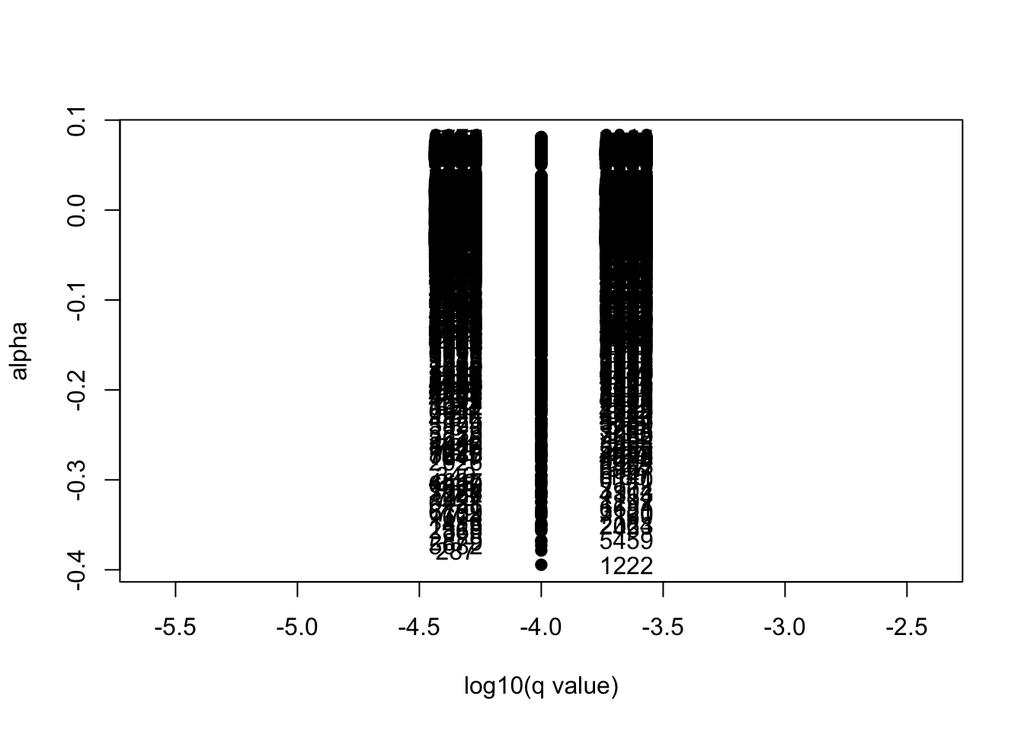

```r
#Forest sites
#Analysis of forest sites using plot_bayescan function
Sg.for.res<-plot_bayescan(Sg.for, #Data
                          FDR=0.01) #False discovery rate
```

```r
#Review the number of outliers detected as candidates under selection
Sg.for.res$nb_outliers #Very large number!
```

```
## [1] 7599
```

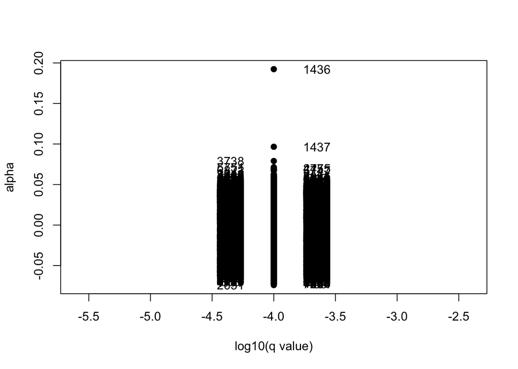

```r
#Agricultural sites
#Analysis of agricultural sites using plot_bayescan function
Sg.agr.res<-plot_bayescan(Sg.agr, #Data
                          FDR=0.01) #False discovery rate
```

```r
#Review the number of outliers detected as candidates under selection
Sg.agr.res$nb_outliers #Very large number!
```

```
## [1] 7599
```

6. False discovery rate correction

```r
#Forest sites
#Estimate the empirical cumulative distribution function (ECDF) for output
Likelihood_Function_F<-ecdf(Sg.for$alpha)
head(Likelihood_Function_F)
```

```
##
## 1 structure(function (v)
## 2 .approxfun(x, y, v, method, yleft, yright, f, na.rm), class = c("ecdf",
## 3 "stepfun", "function"), call = ecdf(Sg.for$alpha))
```

```r
#Function evaluation for output
#Run function
Eval_F<-Likelihood_Function_F(Sg.for[,"alpha"])
#Check results
head(Eval_F)
```

```
## [1] 0.190814581 0.183050401 0.676799579 0.131464666 0.665482300 0.009080142
```

```r
#Calculate the p-value, as 1 - the values of the previous results
Likelihood_Pval_F<-1-Eval_F

#Since many comparisons are made, it is necessary to correct the p-values, which make with the function p.adjust
Likelihood_FDR_F<-p.adjust(Likelihood_Pval_F,"BH") #Correction method used, known as False Discovery Rate
```

```r
#Agricultural sites
#Estimate the empirical cumulative distribution function (ECDF) for output
Likelihood_Function_A<-ecdf(Sg.agr$alpha)

#Function evaluation for output
#Run function
Eval_A<-Likelihood_Function_F(Sg.agr[,"alpha"])
#Check results
head(Eval_A)
```

```
## [1] 0.09132781 0.10317147 0.42966180 0.47979997 0.45677063 0.43887354
```

```r
#Calculate the p-value, as 1 - the values of the previous results
Likelihood_Pval_A<-1-Eval_A

#Since many comparisons are made, it is necessary to correct the p-values, which make with the function p.adjust
Likelihood_FDR_A<-p.adjust(Likelihood_Pval_A,"BH") #Correction method used, known as False Discovery Rate
```

7. Create a new data frame with the results that includes the original data and the adjusted p-values

```r
#Forest sites
#Copy original data
Sg.For.res<-Sg.for

#Add p-values
Sg.For.res$pval<-Likelihood_Pval_F
Sg.For.res$pval.adjust<-Likelihood_FDR_F
head(Sg.For.res)
```

```
##   bayescan_number      prob log10.PO.     qval     alpha     fst      pval
## 1               1 0.0770154  -1.07862 0.905538 -0.029465 0.72952 0.8091854
## 2               2 0.0846170  -1.03410 0.901480 -0.029955 0.72928 0.8169496
## 3               3 0.0882180  -1.01430 0.897810  0.025043 0.73865 0.3232004
## 4               4 0.0782160  -1.07130 0.905160 -0.033308 0.72866 0.8685353
## 5               5 0.0892180  -1.00900 0.896580  0.024373 0.73856 0.3345177
## 6               6 0.1930400  -0.62121 0.780770 -0.241100 0.68263 0.9909199
##   pval.adjust
## 1   0.9995305
## 2   0.9995305
## 3   0.9991867
## 4   0.9996990
## 5   0.9992157
## 6   0.9998672
```

```r
#Eexamine which ones are significant now
sum(Sg.For.res$pval.adjust<=0.001)
```

```
## [1] 1
```

```r
#Agricultural sites
#Copy original data
Sg.Agr.res<-Sg.agr

#Add p-values
Sg.Agr.res$pval<-Likelihood_Pval_A
Sg.Agr.res$pval.adjust<-Likelihood_FDR_A
head(Sg.Agr.res)
```

```
##   bayescan_number     prob log10.PO.     qval      alpha     fst      pval
## 1               1 0.103021 -0.939858 0.893885 -0.0486340 0.27198 0.9086722
## 2               2 0.092218 -0.993160 0.900120 -0.0402090 0.27307 0.8968285
## 3               3 0.072615 -1.106200 0.908650 -0.0123000 0.27632 0.5703382
## 4               4 0.091618 -0.996290 0.900450 -0.0034869 0.27832 0.5202000
## 5               5 0.069614 -1.126000 0.909000 -0.0076189 0.27686 0.5432294
## 6               6 0.085017 -1.031900 0.904110 -0.0108860 0.27691 0.5611265
##   pval.adjust
## 1   0.9310709
## 2   0.9310709
## 3   0.9120508
## 4   0.9120508
## 5   0.9120508
## 6   0.9120508
```

```r
#Eexamine which ones are significant now
sum(Sg.Agr.res$pval.adjust<=0.001)
```

```
## [1] 2
```

8. Explore significant outliers with a plot

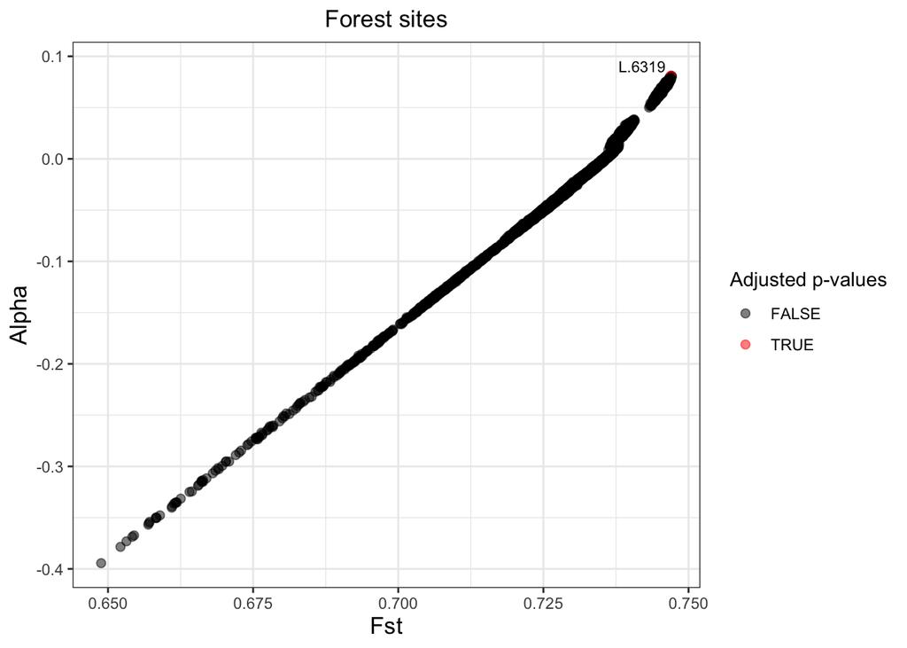

```r
#Forest sites
(Sg.For.out<-ggplot(Sg.For.res,aes(x=fst, y=alpha))+ #Axis definition
                    geom_point(size=2,alpha=0.5, #Geometry definition
                    aes(colour=pval.adjust<=0.001))+ #Points color adjusted to p-val.adjust
                    scale_color_manual(values=c("black","red"))+ #Define point colors
                    theme_bw()+ #Canvas definition
                    ylab("Alpha")+ #y-lab name
                    xlab("Fst")+ #x-lab name
                    labs(color="Adjusted p-values")+ #Rename legend title
                    ggtitle("Forest sites")+ #Put title
                    theme(plot.title=element_text(hjust=0.5), #Center title
                    axis.title.y=element_text(size=13), #y-axis title size
                    axis.title.x=element_text(size=13))+ #x-axis title size
                    annotate("text",x=0.742,y=0.09,label="L.6319",size=3)) #Add candidate SNP name
```

Save plot to pdf file

```r
ggsave("Analysis/BayeScan/Figures/Sg.For.out.pdf",dpi=300,limitsize=TRUE,
       width=10,height=7)
```

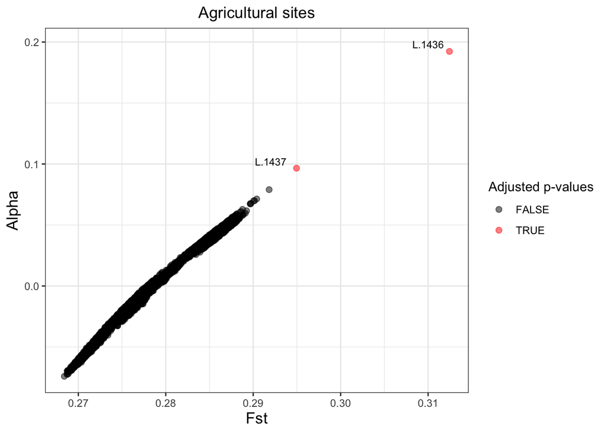

```r
#Agricultural sites
(Sg.Agr.out<-ggplot(Sg.Agr.res,aes(x=fst,y=alpha))+ #Axis definition
                   geom_point(size=2,alpha=0.5, #Geometry definition
                   aes(colour=pval.adjust<=0.001))+ #Points color adjusted to p-val.adjust
                   scale_color_manual(values=c("black","red"))+ #Define point colors
                   theme_bw()+ #Canvas definition
                   ylab("Alpha")+ #y-lab name
                   xlab("Fst")+ #x-lab name
                   labs(color="Adjusted p-values")+ #Rename legend title
                   ggtitle("Agricultural sites")+ #Put title
                   theme(plot.title=element_text(hjust=0.5), #Center title
                   axis.title.y=element_text(size=13), #y-axis title size
                   axis.title.x=element_text(size=13))+ #x-axis title size
                   annotate("text",x=0.31,y=0.198,label="L.1436",size=3)+ #Add candidate SNP name
                   annotate("text",x=0.292,y=0.102,label="L.1437",size=3)) #Add candidate SNP name
```

Save plot to pdf file

```r
ggsave("Analysis/BayeScan/Figures/Sg.Agr.out.pdf",dpi=300,limitsize=TRUE,
       width=10,height=7)
```